# test 3: W2V vs BERT - ranking

[output not shown]

### DATA

Similarities ranking between words and definitions using average and sum as composition functions for w2v and BERT-free-context.

As example we will show w2v.

| w | 1 | 2 | 3 | 4 | 5 | 6 | 7 | 8 | 9 | 10 | 11 | 12 | 13 | 14 | 15 | 16 | 17 | 18 | 19 | 20 | 21 | 22 | 23 | 24 | 25 | 26 | 27 | 28 | 29 | … |
| --- | --- | --- | --- | --- | --- | --- | --- | --- | --- | --- | --- | --- | --- | --- | --- | --- | --- | --- | --- | --- | --- | --- | --- | --- | --- | --- | --- | --- | --- | --- |
| love | love | luxury | prejudice | lover | mind | valor | interest | attempt | kind | food | queen | stock | smart | opera | theater | psychology | school | clothes | morality | jazz | volunteer | tool | preparation | fear | oracle | party | hotel | object | depression | … |
| tiger | tiger | rook | cock | cat | carnivore | jaguar | baby | animal | seafood | fauna | rooster | mammal | lobster | egg | feline | bird | man | organism | boy | zoo | food | mouth | ear | woman | nature | environment | skin | lad | potato | … |
| book | index | journal | library | book | article | listing | archive | film | ticket | board | lesson | media | money | report | cash | paper | astronomer | keyboard | information | motto | lawyer | medal | withdrawal | announcement | party | telephone | museum | science | secretary | … |
| computer | software | hardware | keyboard | computer | internet | office | secretary | phone | video | radio | television | music | laboratory | performance | board | movie | cd | student | viewer | organism | library | card | book | astronomer | infrastructure | article | professor | theater | closet | … |
| plane | flight | plane | airport | car | automobile | crew | bird | voyage | reservation | departure | aluminum | train | animal | phone | arrival | star | environment | water | queen | inmate | shore | journey | deposit | stove | graveyard | thunderstorm | coast | monk | weapon | … |
| train | train | voyage | flight | automobile | crew | airport | car | block | travel | hospital | discipline | party | plane | phone | girl | street | infrastructure | nurse | thunderstorm | marathon | sprint | aluminum | departure | student | personnel | ticket | team | school | row | … |

| w | 1 | 2 | 3 | 4 | 5 | 6 | 7 | 8 | 9 | 10 | 11 | 12 | 13 | 14 | 15 | 16 | 17 | 18 | 19 | 20 | 21 | 22 | 23 | 24 | 25 | 26 | 27 | 28 | 29 | … |
| --- | --- | --- | --- | --- | --- | --- | --- | --- | --- | --- | --- | --- | --- | --- | --- | --- | --- | --- | --- | --- | --- | --- | --- | --- | --- | --- | --- | --- | --- | --- |
| love | 0.47144239 | 0.47002609 | 0.42744012 | 0.40290736 | 0.39935730 | 0.39524970 | 0.38481602 | 0.37227731 | 0.37063673 | 0.36715467 | 0.36654920 | 0.36233658 | 0.36133458 | 0.35756450 | 0.35459799 | 0.35312053 | 0.35234093 | 0.34882703 | 0.34791296 | 0.34716882 | 0.34641924 | 0.34535533 | 0.34517880 | 0.34517270 | 0.34287338 | 0.33954501 | 0.33952009 | 0.33701167 | 0.33684132 | … |
| tiger | 0.454412687 | 0.435577771 | 0.430491449 | 0.425140706 | 0.391204159 | 0.361512395 | 0.361409695 | 0.360603820 | 0.357091165 | 0.352925841 | 0.346360466 | 0.339135297 | 0.329696395 | 0.327436579 | 0.312627859 | 0.297336282 | 0.291428682 | 0.290473166 | 0.288605159 | 0.287815209 | 0.285978914 | 0.271312383 | 0.265421628 | 0.264018435 | 0.260442078 | 0.258074256 | 0.254527112 | 0.251826957 | 0.251685609 | … |
| book | 0.40064742 | 0.37588556 | 0.35384255 | 0.35070528 | 0.33417897 | 0.29138039 | 0.27935991 | 0.26413902 | 0.25744033 | 0.24616828 | 0.24516210 | 0.24434837 | 0.22656041 | 0.22573592 | 0.22471485 | 0.22436751 | 0.22319218 | 0.22142616 | 0.22068731 | 0.21605008 | 0.21505929 | 0.21100308 | 0.21028896 | 0.20948627 | 0.20757905 | 0.20354016 | 0.20282635 | 0.19947050 | 0.19880567 | … |
| computer | 0.68100305 | 0.53889767 | 0.49639969 | 0.44942784 | 0.44405712 | 0.42110563 | 0.39976768 | 0.39740468 | 0.39216852 | 0.38190899 | 0.35738153 | 0.35017308 | 0.33848250 | 0.33347373 | 0.32893775 | 0.32514300 | 0.31580122 | 0.31057385 | 0.30779517 | 0.30308591 | 0.29945254 | 0.29522311 | 0.29412394 | 0.29331031 | 0.29256829 | 0.29191504 | 0.29077538 | 0.29002124 | 0.28298062 | … |
| plane | 0.55917504 | 0.49426857 | 0.47720168 | 0.38829097 | 0.37796983 | 0.37298730 | 0.32884377 | 0.32432115 | 0.32095924 | 0.30342214 | 0.28622959 | 0.26855462 | 0.25913576 | 0.25482290 | 0.25087633 | 0.25086920 | 0.25015829 | 0.24671512 | 0.24532802 | 0.24435686 | 0.24413778 | 0.24308989 | 0.24284181 | 0.24174268 | 0.23903849 | 0.23888326 | 0.23858177 | 0.23349239 | 0.23080733 | … |
| train | 0.358855908 | 0.346606958 | 0.343594478 | 0.340256105 | 0.336322452 | 0.336243003 | 0.310041797 | 0.273647128 | 0.272363880 | 0.268629694 | 0.257207623 | 0.253939084 | 0.247276599 | 0.244322767 | 0.242664002 | 0.242610119 | 0.240825373 | 0.233977895 | 0.233815801 | 0.233726721 | 0.232774022 | 0.231988752 | 0.226233561 | 0.226211620 | 0.225120383 | 0.224869343 | 0.224656532 | 0.223398353 | 0.222995385 | … |

| w | 1 | 2 | 3 | 4 | 5 | 6 | 7 | 8 | 9 | 10 | 11 | 12 | 13 | 14 | 15 | 16 | 17 | 18 | 19 | 20 | 21 | 22 | 23 | 24 | 25 | 26 | 27 | 28 | 29 | … |
| --- | --- | --- | --- | --- | --- | --- | --- | --- | --- | --- | --- | --- | --- | --- | --- | --- | --- | --- | --- | --- | --- | --- | --- | --- | --- | --- | --- | --- | --- | --- |
| love | love | luxury | prejudice | lover | mind | valor | interest | attempt | kind | food | queen | stock | smart | opera | theater | psychology | school | clothes | morality | jazz | volunteer | tool | preparation | fear | oracle | party | hotel | object | depression | … |
| tiger | tiger | rook | cock | cat | carnivore | jaguar | baby | animal | seafood | fauna | rooster | mammal | lobster | egg | feline | bird | man | organism | boy | zoo | food | mouth | ear | woman | nature | environment | skin | lad | potato | … |
| book | index | journal | library | book | article | listing | archive | film | ticket | board | lesson | media | money | report | cash | paper | astronomer | keyboard | information | motto | lawyer | medal | withdrawal | announcement | party | telephone | museum | science | secretary | … |
| computer | software | hardware | keyboard | computer | internet | office | secretary | phone | video | radio | television | music | laboratory | performance | board | movie | cd | student | viewer | organism | library | card | book | astronomer | infrastructure | article | professor | theater | closet | … |
| plane | flight | plane | airport | car | automobile | crew | bird | voyage | reservation | departure | aluminum | train | animal | phone | arrival | star | environment | water | queen | inmate | shore | journey | deposit | stove | graveyard | thunderstorm | coast | monk | weapon | … |
| train | train | voyage | flight | automobile | crew | airport | car | block | travel | hospital | discipline | party | plane | phone | girl | street | infrastructure | nurse | thunderstorm | marathon | sprint | aluminum | departure | student | personnel | ticket | team | school | row | … |

| w | 1 | 2 | 3 | 4 | 5 | 6 | 7 | 8 | 9 | 10 | 11 | 12 | 13 | 14 | 15 | 16 | 17 | 18 | 19 | 20 | 21 | 22 | 23 | 24 | 25 | 26 | 27 | 28 | 29 | … |
| --- | --- | --- | --- | --- | --- | --- | --- | --- | --- | --- | --- | --- | --- | --- | --- | --- | --- | --- | --- | --- | --- | --- | --- | --- | --- | --- | --- | --- | --- | --- |
| love | 0.47144239 | 0.47002609 | 0.42744012 | 0.40290736 | 0.39935730 | 0.39524970 | 0.38481602 | 0.37227731 | 0.37063673 | 0.36715467 | 0.36654920 | 0.36233658 | 0.36133458 | 0.35756450 | 0.35459799 | 0.35312053 | 0.35234093 | 0.34882703 | 0.34791296 | 0.34716882 | 0.34641924 | 0.34535533 | 0.34517880 | 0.34517270 | 0.34287338 | 0.33954501 | 0.33952009 | 0.33701167 | 0.33684132 | … |
| tiger | 0.454412687 | 0.435577771 | 0.430491449 | 0.425140706 | 0.391204159 | 0.361512395 | 0.361409695 | 0.360603820 | 0.357091165 | 0.352925841 | 0.346360466 | 0.339135297 | 0.329696395 | 0.327436579 | 0.312627859 | 0.297336282 | 0.291428682 | 0.290473166 | 0.288605159 | 0.287815209 | 0.285978914 | 0.271312383 | 0.265421628 | 0.264018435 | 0.260442078 | 0.258074256 | 0.254527112 | 0.251826957 | 0.251685609 | … |
| book | 0.40064742 | 0.37588556 | 0.35384255 | 0.35070528 | 0.33417897 | 0.29138039 | 0.27935991 | 0.26413902 | 0.25744033 | 0.24616828 | 0.24516210 | 0.24434837 | 0.22656041 | 0.22573592 | 0.22471485 | 0.22436751 | 0.22319218 | 0.22142616 | 0.22068731 | 0.21605008 | 0.21505929 | 0.21100308 | 0.21028896 | 0.20948627 | 0.20757905 | 0.20354016 | 0.20282635 | 0.19947050 | 0.19880567 | … |
| computer | 0.68100305 | 0.53889767 | 0.49639969 | 0.44942784 | 0.44405712 | 0.42110563 | 0.39976768 | 0.39740468 | 0.39216852 | 0.38190899 | 0.35738153 | 0.35017308 | 0.33848250 | 0.33347373 | 0.32893775 | 0.32514300 | 0.31580122 | 0.31057385 | 0.30779517 | 0.30308591 | 0.29945254 | 0.29522311 | 0.29412394 | 0.29331031 | 0.29256829 | 0.29191504 | 0.29077538 | 0.29002124 | 0.28298062 | … |
| plane | 0.55917504 | 0.49426857 | 0.47720168 | 0.38829097 | 0.37796983 | 0.37298730 | 0.32884377 | 0.32432115 | 0.32095924 | 0.30342214 | 0.28622959 | 0.26855462 | 0.25913576 | 0.25482290 | 0.25087633 | 0.25086920 | 0.25015829 | 0.24671512 | 0.24532802 | 0.24435686 | 0.24413778 | 0.24308989 | 0.24284181 | 0.24174268 | 0.23903849 | 0.23888326 | 0.23858177 | 0.23349239 | 0.23080733 | … |
| train | 0.358855908 | 0.346606958 | 0.343594478 | 0.340256105 | 0.336322452 | 0.336243003 | 0.310041797 | 0.273647128 | 0.272363880 | 0.268629694 | 0.257207623 | 0.253939084 | 0.247276599 | 0.244322767 | 0.242664002 | 0.242610119 | 0.240825373 | 0.233977895 | 0.233815801 | 0.233726721 | 0.232774022 | 0.231988752 | 0.226233561 | 0.226211620 | 0.225120383 | 0.224869343 | 0.224656532 | 0.223398353 | 0.222995385 | … |

Analogous for BERT representation.

NOTE: the same cosine similarities for average and sum!!!! …but really the compound vector is different

### RANKING

We study this rankings

#### w2v compound using words definition average

We can plot the average of similarities with maximum and minimum values,

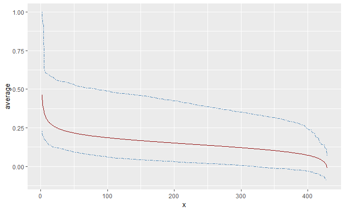

We can observe that there is similarities equal to one. We review words with simialrity equal to one.

| w | 1 | 2 | 3 | 4 | 5 | 6 | 7 | 8 | 9 | 10 | 11 | 12 | 13 | 14 | 15 | 16 | 17 | 18 | 19 | 20 | 21 | 22 | 23 | 24 | 25 | 26 | 27 | 28 | 29 | … |
| --- | --- | --- | --- | --- | --- | --- | --- | --- | --- | --- | --- | --- | --- | --- | --- | --- | --- | --- | --- | --- | --- | --- | --- | --- | --- | --- | --- | --- | --- | --- |
| car | 1.00000000 | 0.55202201 | 0.45214538 | 0.44602932 | 0.40692368 | 0.35295388 | 0.33318165 | 0.33141156 | 0.32098384 | 0.31299695 | 0.30934790 | 0.28915907 | 0.28913258 | 0.28781592 | 0.28604874 | 0.27970821 | 0.27820282 | 0.27732201 | 0.27676494 | 0.27537779 | 0.27461140 | 0.27415299 | 0.27105501 | 0.26962949 | 0.26184002 | 0.26136436 | 0.26034395 | 0.25917100 | 0.25910902 | … |
| calculation | 1.0000000000 | 0.4492906353 | 0.3446186744 | 0.3106780356 | 0.2924155860 | 0.2782054336 | 0.2717855103 | 0.2707849992 | 0.2678088460 | 0.2660955829 | 0.2647975908 | 0.2630841485 | 0.2624652450 | 0.2607815198 | 0.2588480689 | 0.2562459288 | 0.2520388036 | 0.2508330921 | 0.2503185276 | 0.2491553441 | 0.2487957412 | 0.2450022395 | 0.2439785437 | 0.2429215202 | 0.2423067099 | 0.2422205292 | 0.2406652911 | 0.2404297430 | 0.2367231917 | … |
| dollar | 1.00000000 | 0.33452383 | 0.31103244 | 0.30475564 | 0.30299712 | 0.30284018 | 0.28258589 | 0.27566663 | 0.27480981 | 0.26835155 | 0.26801952 | 0.26751876 | 0.26704378 | 0.26551155 | 0.26550941 | 0.26227635 | 0.26069640 | 0.26043489 | 0.25560869 | 0.25461151 | 0.25407956 | 0.25403186 | 0.25401265 | 0.25026215 | 0.24903102 | 0.24692886 | 0.24674715 | 0.24490002 | 0.24089034 | … |

| w | 1 | 2 | 3 | 4 | 5 | 6 | 7 | 8 | 9 | 10 | 11 | 12 | 13 | 14 | 15 | 16 | 17 | 18 | 19 | 20 | 21 | 22 | 23 | 24 | 25 | 26 | 27 | 28 | 29 | … |
| --- | --- | --- | --- | --- | --- | --- | --- | --- | --- | --- | --- | --- | --- | --- | --- | --- | --- | --- | --- | --- | --- | --- | --- | --- | --- | --- | --- | --- | --- | --- |
| car | automobile | car | plane | departure | train | aluminum | weapon | airport | marathon | reservation | grocery | flight | block | withdrawal | closet | boy | cup | girl | bed | shower | computer | murder | stove | keyboard | insurance | crew | hotel | baby | queen | … |
| calculation | computation | number | calculation | science | stupid | kilometer | payment | software | sign | implement | chemistry | listing | motto | index | benchmark | computer | metal | physics | president | precedent | registration | mile | hardware | proton | earning | price | secret | category | recognition | … |
| dollar | buck | profit | dividend | planet | trading | cash | money | price | wealth | yen | payment | star | furnace | dollar | bank | oil | earning | moon | train | tennis | production | medal | opec | investor | withdrawal | insurance | library | egg | victory | … |

And we can count the number of definitions equal to word in each ranking position,

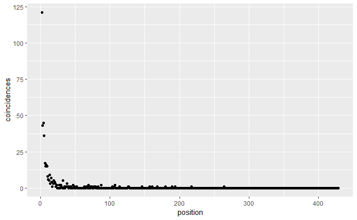

#### BERT (free-context) compound using words definition average

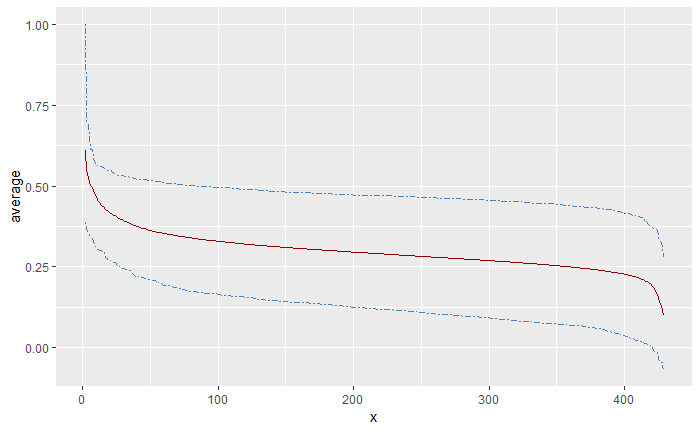

We can observe similarity values (we remember that we are using the cosine similarity) highest than w2v. In the same way, we can review words with similarity equal to one,

| w | 1 | 2 | 3 |
| --- | --- | --- | --- |
| calculation | 1.0000000 | 0.5586618 | 0.5448134 |

And we can count the number of definitions equal to word in each ranking position,

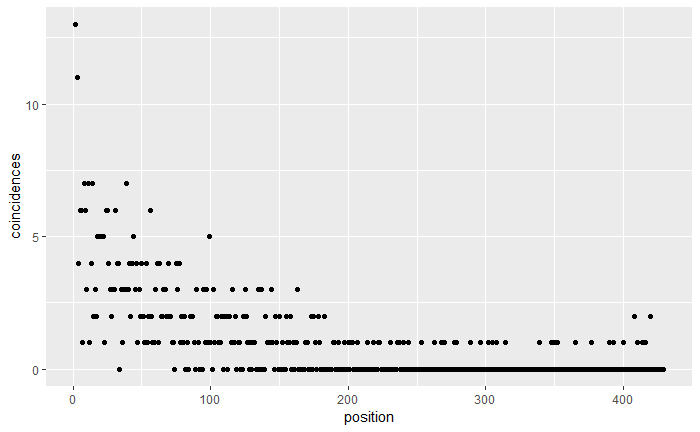

We observe a different behaviour in w2v and BERT. With w2v we observe that the first positions (30 - 50) in the ranking acummulate o lot of correct definitions, nevertheless, BERT looks ñike more distributed.

In this point the text used to training each model can take importance.